# Relatório AB1.1 - Probabilidade e Estatística

Jean Felipe Duarte Tenório

Jayme Vinicius Esteves Pedroza Melo

Petrúcio Antônio Medeiros Barros (Professor)

12-08-2025

# **Contexto Geral do Projeto de acordo com a base de dados Escolhida:**

# Introdução e Contexto do Trabalho

Este trabalho tem como objetivo realizar uma **Análise Exploratória de Dados (AED)** e aplicar técnicas estatísticas descritivas e bivariadas para compreender padrões e relações presentes na base de dados escolhida. Todas as análises serão desenvolvidas no **R**.

## Contexto Geral da Base de Dados

O conjunto de dados **“Estimation of Obesity Levels Based on Eating Habits and Physical Condition”** foi disponibilizado no **UCI Machine Learning Repository** em 26 de agosto de 2019.  
Ele contém informações sobre **hábitos alimentares**, **condições físicas** e **características demográficas** de **2 111 indivíduos** de **México, Peru e Colômbia**, com idades entre **14 e 61 anos**.

O objetivo principal é **estimar o nível de obesidade** com base nas variáveis coletadas.  
A variável-alvo **`NObesity`** (Nível de Obesidade) possui sete categorias: - Abaixo do Peso - Peso Normal - Sobrepeso Nível 1 - Sobrepeso Nível 2 - Obesidade Nível 1 - Obesidade Nível 2 - Obesidade Nível 3.

### Composição dos Dados

| Tipo de Variável | Atributos |
| --- | --- |
| **Demográficas** | `Gender`, `Age`, `Height`, `Weight`, `family_history_with_overweight` |
| **Hábitos alimentares** | `FAVC` (alta caloria), `FCVC` (vegetais), `NCP` (refeições), `CAEC` (entre refeições), `CH2O` (água), `CALC` (álcool) |
| **Condição física** | `SCC` (monitoramento de calorias), `FAF` (atividade física), `TUE` (uso de tecnologia), `MTRANS` (transporte) |
| **Variável alvo** | `NObesity` (nível de obesidade) |

Todos os registros são **completos**, sem valores ausentes.

### Origem dos Dados

- **77% dos registros** foram gerados sinteticamente usando **WEKA** e o filtro **SMOTE** para balanceamento de classes.
- **23% dos registros** foram coletados diretamente por meio de uma plataforma web, com respostas fornecidas pelos próprios participantes.

## Estrutura do Trabalho

### 1. Preparação e Análise Exploratória de Dados

- Importar a base para o R e identificar número de linhas e colunas.
- Criar um dicionário de dados com a descrição de cada variável.
- Padronizar nomes das colunas e valores categóricos.
- Verificar e tratar valores inconsistentes ou outliers.
- Salvar a base limpa em formato `.xlsx`.

### 2. Estatísticas Descritivas de uma Variável Numérica

- Selecionar uma variável numérica contínua.
- Calcular mínimo, máximo, média, mediana, desvio padrão e quartis.
- Construir histograma e boxplot, interpretando os resultados.

### 3. Análise Bivariada de Duas Variáveis Categóricas

- Escolher duas variáveis categóricas.
- Criar gráficos de barras comparativos.
- Interpretar padrões e relações encontradas.

### 4. Boxplot entre Variável Numérica e Categórica

- Relacionar uma variável numérica contínua e uma categórica.
- Construir boxplot e justificar a escolha das variáveis.
- Interpretar diferenças entre os grupos.

### 5. Matriz de Correlação

- Calcular e visualizar a matriz de correlação entre todas as variáveis numéricas.
- Explicar as correlações mais relevantes encontradas.

### 6. Análise Bivariada de Duas Variáveis Numéricas

- Escolher duas variáveis numéricas.
- Criar gráfico de dispersão com linha de tendência.
- Calcular a equação da reta ajustada, a correlação e o coeficiente de determinação (R²).

### 7. Formulação e Teste de Três Perguntas

- Criar três perguntas envolvendo análise bivariada.
- Utilizar gráficos ou análises estatísticas para confirmar ou refutar as hipóteses.
- Interpretar cada resultado obtido.

## Entregas

- Código-fonte em R (`.R`) e `.Rmd`
- Arquivo Excel com base tratada
- Relatório em HTML ou PDF
- Apresentação de até 7 minutos com principais descobertas

# 1. Preparação e Análise Exploratória de Dados

Nesta etapa, realizamos a preparação inicial da base escolhida, contemplando:

- Importação e inspeção inicial;
- Seleção e renomeação de variáveis;
- Padronização e tradução de valores categóricos;
- Tratamento de tipos de dados;
- Arredondamento de valores numéricos;
- Exportação da base limpa.

## 1.1. Limpeza do ambiente

### 1.1.1. Remove todos os objetos carregados na sessão.

```r
rm(list = ls())
```

## 1.2. Definir Diretório dos Arquivos

```r
setwd("C:/Users/Jean/Desktop/Trabalho_Probabilidade")
```

## 1.3. Importação da Base Original

```r
Obesidade_raw <- read.csv(
  "ObesityDataSet_raw_and_data_sinthetic.csv",
  header = TRUE, sep = ",", dec = "."
)
```

### 1.3.1. Primeiras linhas

```r
head(Obesidade_raw)
```

|  | Gender | Age | Height | Weight | family_history_with_overweight | FAVC | FCVC | NCP | CAEC | SMOKE | CH2O | SCC | FAF | TUE | CALC | MTRANS | NObeyesdad |
| --- | --- | --- | --- | --- | --- | --- | --- | --- | --- | --- | --- | --- | --- | --- | --- | --- | --- |
| 1 | Female | 21 | 1.62 | 64.0 | yes | no | 2 | 3 | Sometimes | no | 2 | no | 0 | 1 | no | Public_Transportation | Normal_Weight |
| 2 | Female | 21 | 1.52 | 56.0 | yes | no | 3 | 3 | Sometimes | yes | 3 | yes | 3 | 0 | Sometimes | Public_Transportation | Normal_Weight |
| 3 | Male | 23 | 1.80 | 77.0 | yes | no | 2 | 3 | Sometimes | no | 2 | no | 2 | 1 | Frequently | Public_Transportation | Normal_Weight |
| 4 | Male | 27 | 1.80 | 87.0 | no | no | 3 | 3 | Sometimes | no | 2 | no | 2 | 0 | Frequently | Walking | Overweight_Level_I |
| 5 | Male | 22 | 1.78 | 89.8 | no | no | 2 | 1 | Sometimes | no | 2 | no | 0 | 0 | Sometimes | Public_Transportation | Overweight_Level_II |
| 6 | Male | 29 | 1.62 | 53.0 | no | yes | 2 | 3 | Sometimes | no | 2 | no | 0 | 0 | Sometimes | Automobile | Normal_Weight |

```r
tail(Obesidade_raw)
```

|  | Gender | Age | Height | Weight | family_history_with_overweight | FAVC | FCVC | NCP | CAEC | SMOKE | CH2O | SCC | FAF | TUE | CALC | MTRANS | NObeyesdad |
| --- | --- | --- | --- | --- | --- | --- | --- | --- | --- | --- | --- | --- | --- | --- | --- | --- | --- |
| 2106 | Female | 21.28597 | 1.726920 | 131.3358 | yes | yes | 3 | 3 | Sometimes | no | 1.796267 | no | 1.728332 | 0.897924 | Sometimes | Public_Transportation | Obesity_Type_III |
| 2107 | Female | 20.97684 | 1.710730 | 131.4085 | yes | yes | 3 | 3 | Sometimes | no | 1.728139 | no | 1.676269 | 0.906247 | Sometimes | Public_Transportation | Obesity_Type_III |
| 2108 | Female | 21.98294 | 1.748584 | 133.7429 | yes | yes | 3 | 3 | Sometimes | no | 2.005130 | no | 1.341390 | 0.599270 | Sometimes | Public_Transportation | Obesity_Type_III |
| 2109 | Female | 22.52404 | 1.752206 | 133.6894 | yes | yes | 3 | 3 | Sometimes | no | 2.054193 | no | 1.414209 | 0.646288 | Sometimes | Public_Transportation | Obesity_Type_III |
| 2110 | Female | 24.36194 | 1.739450 | 133.3466 | yes | yes | 3 | 3 | Sometimes | no | 2.852339 | no | 1.139107 | 0.586035 | Sometimes | Public_Transportation | Obesity_Type_III |
| 2111 | Female | 23.66471 | 1.738836 | 133.4726 | yes | yes | 3 | 3 | Sometimes | no | 2.863513 | no | 1.026452 | 0.714137 | Sometimes | Public_Transportation | Obesity_Type_III |

### 1.3.2. Resumo estatístico inicial

```r
summary(Obesidade_raw)
```

```
##     Gender               Age            Height          Weight
##  Length:2111        Min.   :14.00   Min.   :1.450   Min.   : 39.00
##  Class :character   1st Qu.:19.95   1st Qu.:1.630   1st Qu.: 65.47
##  Mode  :character   Median :22.78   Median :1.700   Median : 83.00
##                     Mean   :24.31   Mean   :1.702   Mean   : 86.59
##                     3rd Qu.:26.00   3rd Qu.:1.768   3rd Qu.:107.43
##                     Max.   :61.00   Max.   :1.980   Max.   :173.00
##  family_history_with_overweight     FAVC                FCVC
##  Length:2111                    Length:2111        Min.   :1.000
##  Class :character               Class :character   1st Qu.:2.000
##  Mode  :character               Mode  :character   Median :2.386
##                                                    Mean   :2.419
##                                                    3rd Qu.:3.000
##                                                    Max.   :3.000
##       NCP            CAEC              SMOKE                CH2O
##  Min.   :1.000   Length:2111        Length:2111        Min.   :1.000
##  1st Qu.:2.659   Class :character   Class :character   1st Qu.:1.585
##  Median :3.000   Mode  :character   Mode  :character   Median :2.000
##  Mean   :2.686                                         Mean   :2.008
##  3rd Qu.:3.000                                         3rd Qu.:2.477
##  Max.   :4.000                                         Max.   :3.000
##      SCC                 FAF              TUE             CALC
##  Length:2111        Min.   :0.0000   Min.   :0.0000   Length:2111
##  Class :character   1st Qu.:0.1245   1st Qu.:0.0000   Class :character
##  Mode  :character   Median :1.0000   Median :0.6253   Mode  :character
##                     Mean   :1.0103   Mean   :0.6579
##                     3rd Qu.:1.6667   3rd Qu.:1.0000
##                     Max.   :3.0000   Max.   :2.0000
##     MTRANS           NObeyesdad
##  Length:2111        Length:2111
##  Class :character   Class :character
##  Mode  :character   Mode  :character
##
##
##
```

### 1.3.3. Nomes originais das colunas

```r
names(Obesidade_raw)
```

```
##  [1] "Gender"                         "Age"
##  [3] "Height"                         "Weight"
##  [5] "family_history_with_overweight" "FAVC"
##  [7] "FCVC"                           "NCP"
##  [9] "CAEC"                           "SMOKE"
## [11] "CH2O"                           "SCC"
## [13] "FAF"                            "TUE"
## [15] "CALC"                           "MTRANS"
## [17] "NObeyesdad"
```

## 1.4. Seleção das Colunas Relevantes

```r
Obesidade_clean <- Obesidade_raw[, c(
  "Gender", "Age", "Weight", "Height", "family_history_with_overweight",
  "FAVC", "FCVC", "NCP", "CAEC", "SMOKE", "CH2O", "SCC",
  "FAF", "TUE", "CALC", "MTRANS", "NObeyesdad"
)]
```

## 1.5. Renomeação de Variáveis

```r
names(Obesidade_clean) <- c(
  "Genero", "Idade", "Peso", "Altura", "Historico_Familiar_Obesidade",
  "Comida_Alta_Caloria", "Consumo_Vegetais", "Refeicoes_Diarias", "Comer_Entre_Refeicoes",
  "Fumante", "Agua_Diaria", "Monitora_Calorias", "Atividade_Fisica",
  "Uso_Tecnologia", "Consumo_Alcool", "Meio_Transporte", "Nivel_Obesidade"
)

names(Obesidade_clean)
```

```
##  [1] "Genero"                       "Idade"
##  [3] "Peso"                         "Altura"
##  [5] "Historico_Familiar_Obesidade" "Comida_Alta_Caloria"
##  [7] "Consumo_Vegetais"             "Refeicoes_Diarias"
##  [9] "Comer_Entre_Refeicoes"        "Fumante"
## [11] "Agua_Diaria"                  "Monitora_Calorias"
## [13] "Atividade_Fisica"             "Uso_Tecnologia"
## [15] "Consumo_Alcool"               "Meio_Transporte"
## [17] "Nivel_Obesidade"
```

## 1.6. Padronização e Tradução de Valores Categóricos

### 1.6.1. Gênero

```r
Obesidade_clean$Genero <- c("Masculino", "Feminino")[match(Obesidade_clean$Genero, c("Male", "Female"))]
```

### 1.6.2. Variáveis binárias

```r
binarios_en <- c("yes", "no")
binarios_pt <- c("Sim", "Não")
Obesidade_clean$Historico_Familiar_Obesidade <- binarios_pt[match(Obesidade_clean$Historico_Familiar_Obesidade, binarios_en)]
Obesidade_clean$Comida_Alta_Caloria <- binarios_pt[match(Obesidade_clean$Comida_Alta_Caloria, binarios_en)]
Obesidade_clean$Fumante <- binarios_pt[match(Obesidade_clean$Fumante, binarios_en)]
Obesidade_clean$Monitora_Calorias <- binarios_pt[match(Obesidade_clean$Monitora_Calorias, binarios_en)]
```

### 1.6.3. Categorias de frequência

```r
freq_en <- c("no","Sometimes","Frequently","Always")
freq_pt <- c("Não","Às Vezes","Frequentemente","Sempre")
Obesidade_clean$Comer_Entre_Refeicoes <- freq_pt[match(Obesidade_clean$Comer_Entre_Refeicoes, freq_en)]
Obesidade_clean$Consumo_Alcool <- freq_pt[match(Obesidade_clean$Consumo_Alcool, freq_en)]
```

### 1.6.4. Meio de transporte

```r
transport_en <- c("Automobile","Bike","Motorbike","Public_Transportation","Walking")
transport_pt <- c("Carro","Bicicleta","Moto","Transporte Público","À Pé")
Obesidade_clean$Meio_Transporte <- transport_pt[match(Obesidade_clean$Meio_Transporte, transport_en)]
```

### 1.6.5. Níveis de obesidade

```r
nivel_en <- c("Insufficient_Weight","Normal_Weight","Overweight_Level_I","Overweight_Level_II","Obesity_Type_I","Obesity_Type_II","Obesity_Type_III")
nivel_pt <- c("Abaixo do Peso","Peso Normal","Sobrepeso Nível 1","Sobrepeso Nível 2","Obesidade Nível 1","Obesidade Nível 2","Obesidade Nível 3")
Obesidade_clean$Nivel_Obesidade <- nivel_pt[match(Obesidade_clean$Nivel_Obesidade, nivel_en)]
```

## 1.7. Tratamento de valores numéricos

```r
Obesidade_clean$Peso <- round(Obesidade_clean$Peso, 1)
Obesidade_clean$Altura <- round(Obesidade_clean$Altura, 2)
Obesidade_clean$Idade <- as.integer(round(Obesidade_clean$Idade))
Obesidade_clean$Agua_Diaria <- round(Obesidade_clean$Agua_Diaria, 2)
Obesidade_clean$Uso_Tecnologia <- as.integer(Obesidade_clean$Uso_Tecnologia)
Obesidade_clean$Atividade_Fisica <- round(Obesidade_clean$Atividade_Fisica, 1)
```

### 1.7.1. Uso de Tecnologia Conversão

```r
valores_antigos5 <- c("0","1","2")
valores_novos5 <- c("Pouco","Moderado","Prolongado")
Obesidade_clean$Uso_Tecnologia <- valores_novos5[match(Obesidade_clean$Uso_Tecnologia, valores_antigos5)]
```

### 1.7.2. Consumo de vegetais e refeições diárias

```r
Obesidade_clean$Consumo_Vegetais <- as.integer(Obesidade_clean$Consumo_Vegetais)
Obesidade_clean$Refeicoes_Diarias <- as.integer(Obesidade_clean$Refeicoes_Diarias)
valores_antigos5 <- c("1","2","3")
valores_novos5 <- c("Pouco","Frequentemente","Sempre")
Obesidade_clean$Consumo_Vegetais <- valores_novos5[match(Obesidade_clean$Consumo_Vegetais, valores_antigos5)]
```

## 1.8. Estrutura e tipos de variáveis

```r
typeof(Obesidade_clean$Consumo_Vegetais)
```

```
## [1] "character"
```

```r
typeof(Obesidade_clean$Refeicoes_Diarias)
```

```
## [1] "integer"
```

```r
typeof(Obesidade_clean$Genero)
```

```
## [1] "character"
```

```r
typeof(Obesidade_clean$Idade)
```

```
## [1] "integer"
```

```r
typeof(Obesidade_clean$Uso_Tecnologia)
```

```
## [1] "character"
```

```r
typeof(Obesidade_clean$Atividade_Fisica)
```

```
## [1] "double"
```

```r
typeof(Obesidade_clean$Peso)
```

```
## [1] "double"
```

```r
typeof(Obesidade_clean$Consumo_Alcool)
```

```
## [1] "character"
```

```r
typeof(Obesidade_clean$Altura)
```

```
## [1] "double"
```

```r
typeof(Obesidade_clean$Historico_Familiar_Obesidade)
```

```
## [1] "character"
```

```r
typeof(Obesidade_clean$Fumante)
```

```
## [1] "character"
```

```r
typeof(Obesidade_clean$Meio_Transporte)
```

```
## [1] "character"
```

```r
typeof(Obesidade_clean$Comida_Alta_Caloria)
```

```
## [1] "character"
```

```r
typeof(Obesidade_clean$Nivel_Obesidade)
```

```
## [1] "character"
```

```r
typeof(Obesidade_clean$Comer_Entre_Refeicoes)
```

```
## [1] "character"
```

```r
typeof(Obesidade_clean$Agua_Diaria)
```

```
## [1] "double"
```

```r
typeof(Obesidade_clean$Monitora_Calorias)
```

```
## [1] "character"
```

```r
str(Obesidade_clean)
```

```
## 'data.frame':    2111 obs. of  17 variables:
##  $ Genero                      : chr  "Feminino" "Feminino" "Masculino" "Masculino" ...
##  $ Idade                       : int  21 21 23 27 22 29 23 22 24 22 ...
##  $ Peso                        : num  64 56 77 87 89.8 53 55 53 64 68 ...
##  $ Altura                      : num  1.62 1.52 1.8 1.8 1.78 1.62 1.5 1.64 1.78 1.72 ...
##  $ Historico_Familiar_Obesidade: chr  "Sim" "Sim" "Sim" "Não" ...
##  $ Comida_Alta_Caloria         : chr  "Não" "Não" "Não" "Não" ...
##  $ Consumo_Vegetais            : chr  "Frequentemente" "Sempre" "Frequentemente" "Sempre" ...
##  $ Refeicoes_Diarias           : int  3 3 3 3 1 3 3 3 3 3 ...
##  $ Comer_Entre_Refeicoes       : chr  "Às Vezes" "Às Vezes" "Às Vezes" "Às Vezes" ...
##  $ Fumante                     : chr  "Não" "Sim" "Não" "Não" ...
##  $ Agua_Diaria                 : num  2 3 2 2 2 2 2 2 2 2 ...
##  $ Monitora_Calorias           : chr  "Não" "Sim" "Não" "Não" ...
##  $ Atividade_Fisica            : num  0 3 2 2 0 0 1 3 1 1 ...
##  $ Uso_Tecnologia              : chr  "Moderado" "Pouco" "Moderado" "Pouco" ...
##  $ Consumo_Alcool              : chr  "Não" "Às Vezes" "Frequentemente" "Frequentemente" ...
##  $ Meio_Transporte             : chr  "Transporte Público" "Transporte Público" "Transporte Público" "À Pé" ...
##  $ Nivel_Obesidade             : chr  "Peso Normal" "Peso Normal" "Peso Normal" "Sobrepeso Nível 1" ...
```

## 1.9. Conversão para fator

```r
dados <- c(
  "Genero",
  "Historico_Familiar_Obesidade",
  "Comida_Alta_Caloria",
  "Consumo_Vegetais",
  "Comer_Entre_Refeicoes",
  "Fumante",
  "Monitora_Calorias",
  "Uso_Tecnologia",
  "Consumo_Alcool",
  "Meio_Transporte",
  "Nivel_Obesidade"
)

Obesidade_clean[dados] <- lapply(Obesidade_clean[dados], factor)
str(Obesidade_clean)
```

```
## 'data.frame':    2111 obs. of  17 variables:
##  $ Genero                      : Factor w/ 2 levels "Feminino","Masculino": 1 1 2 2 2 2 1 2 2 2 ...
##  $ Idade                       : int  21 21 23 27 22 29 23 22 24 22 ...
##  $ Peso                        : num  64 56 77 87 89.8 53 55 53 64 68 ...
##  $ Altura                      : num  1.62 1.52 1.8 1.8 1.78 1.62 1.5 1.64 1.78 1.72 ...
##  $ Historico_Familiar_Obesidade: Factor w/ 2 levels "Não","Sim": 2 2 2 1 1 1 2 1 2 2 ...
##  $ Comida_Alta_Caloria         : Factor w/ 2 levels "Não","Sim": 1 1 1 1 1 2 2 1 2 2 ...
##  $ Consumo_Vegetais            : Factor w/ 3 levels "Frequentemente",..: 1 3 1 3 1 1 3 1 3 1 ...
##  $ Refeicoes_Diarias           : int  3 3 3 3 1 3 3 3 3 3 ...
##  $ Comer_Entre_Refeicoes       : Factor w/ 4 levels "Às Vezes","Frequentemente",..: 1 1 1 1 1 1 1 1 1 1 ...
##  $ Fumante                     : Factor w/ 2 levels "Não","Sim": 1 2 1 1 1 1 1 1 1 1 ...
##  $ Agua_Diaria                 : num  2 3 2 2 2 2 2 2 2 2 ...
##  $ Monitora_Calorias           : Factor w/ 2 levels "Não","Sim": 1 2 1 1 1 1 1 1 1 1 ...
##  $ Atividade_Fisica            : num  0 3 2 2 0 0 1 3 1 1 ...
##  $ Uso_Tecnologia              : Factor w/ 3 levels "Moderado","Pouco",..: 1 2 1 2 2 2 2 2 1 1 ...
##  $ Consumo_Alcool              : Factor w/ 4 levels "Às Vezes","Frequentemente",..: 3 1 2 2 1 1 1 1 2 3 ...
##  $ Meio_Transporte             : Factor w/ 5 levels "À Pé","Bicicleta",..: 5 5 5 1 5 3 4 5 5 5 ...
##  $ Nivel_Obesidade             : Factor w/ 7 levels "Abaixo do Peso",..: 5 5 5 6 7 5 5 5 5 5 ...
```

## 1.10. Exportação da Base em formato XLSX

```r
write.csv(
  Obesidade_clean,
  file = "Obesidade_clean.csv",
  row.names = FALSE,
  fileEncoding = "UTF-8"
)

library(openxlsx)
write.xlsx(Obesidade_clean, file = "Obesidade_clean.xlsx")
```

## 2. Estatísticas Descritivas de uma Variável Numérica (Peso)

### 2.1. Estatísticas Básicas

```r
setwd("C:/Users/Jean/Desktop/Trabalho_Probabilidade")
obesidade <- read.csv("Obesidade_clean.csv")
obesidade<- within(obesidade, {
  Genero                      <- factor(Genero)
  Historico_Familiar_Obesidade<- factor(Historico_Familiar_Obesidade)
  Comida_Alta_Caloria         <- factor(Comida_Alta_Caloria)
  Consumo_Vegetais            <- factor(Consumo_Vegetais)
  Comer_Entre_Refeicoes       <- factor(Comer_Entre_Refeicoes)
  Fumante                     <- factor(Fumante)
  Monitora_Calorias           <- factor(Monitora_Calorias)
  Uso_Tecnologia              <- factor(Uso_Tecnologia)
  Consumo_Alcool              <- factor(Consumo_Alcool)
  Meio_Transporte             <- factor(Meio_Transporte)
  Nivel_Obesidade             <- factor(Nivel_Obesidade)
})
maximo_obesidade <- max(obesidade$Peso)
minimo_obesidade <- min(obesidade$Peso)
media_obesidade <- mean(obesidade$Peso)
mediana_obesidade <- median(obesidade$Peso)
desvio_padr_obesidade <- sd(obesidade$Peso)
quartis_obesidade <- quantile(obesidade$Peso)
Amplitude_obesidade <- maximo_obesidade - minimo_obesidade

Nclasses <- nclass.Sturges(obesidade$Peso); Nclasses
```

```
## [1] 13
```

```r
amplitude_classes <- ceiling(Amplitude_obesidade / Nclasses)

limiteclas <- seq(minimo_obesidade,maximo_obesidade + amplitude_classes,by = amplitude_classes)

classes <- c(
  "39 |- 50",
  "50 |- 61",
  "61 |- 72",
  "72 |- 83",
  "83 |- 94",
  "94 |- 105",
  "105 |- 116",
  "116 |- 127",
  "127 |- 138",
  "138 |- 149",
  "149 |- 160",
  "160 |- 171",
  "171 |- 182"
)

Freq = table(cut(obesidade$Peso, breaks = limiteclas, right=FALSE,
                 labels=classes))
FreqAc <- cumsum(Freq);
FreqRel <- prop.table(Freq);
FreqRelAc <- cumsum(FreqRel)

TabResul = cbind(Freq,
                 FreqAc,
                 FreqRel = round(FreqRel*100,digits = 2),
                 FreqRelAc= round(FreqRelAc*100,digits = 2))
```

### 2.2. Exibição do Histograma

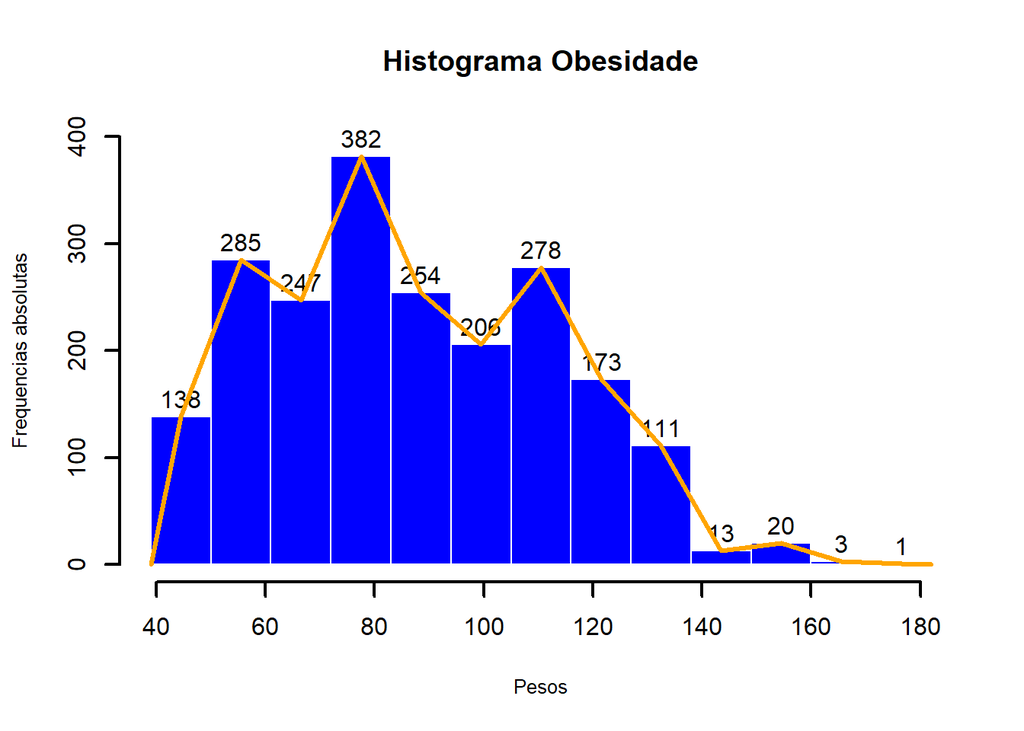

```r
Pesos <- obesidade$Peso

h <- hist(Pesos, breaks=limiteclas,
         ylab="Frequencias absolutas",  labels=TRUE,cex.lab = 0.8,main="Histograma Obesidade",
         xlim=c(39,182), ylim = c (0,400), col="blue",right=FALSE,border="white",lwd=2)
lines(c(min(h$breaks), h$mids, max(h$breaks)),
      c(0,h$counts, 0), type = "l", col="orange",lwd=3)
```

### 2.3. Exibição do Boxplot da Variável Numérica Peso

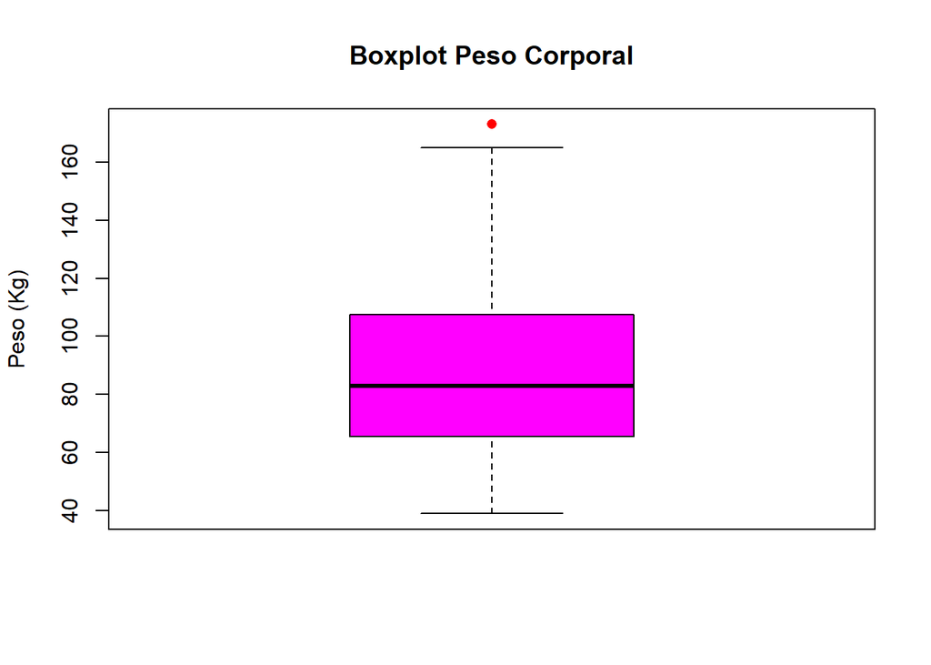

```r
boxplot(obesidade$Peso,  col = "magenta",main="Boxplot Peso Corporal",ylab="Peso (Kg)",outcol="red",outpch = 16)
```

## 3.Análise Bivariada de Duas Variáveis

### 3.1. Convertendo para factor Nivel de Obesidade para garantir a classificação Ordinal

```
## 'data.frame':    2111 obs. of  17 variables:
##  $ Genero                      : Factor w/ 2 levels "Feminino","Masculino": 1 1 2 2 2 2 1 2 2 2 ...
##  $ Idade                       : int  21 21 23 27 22 29 23 22 24 22 ...
##  $ Peso                        : num  64 56 77 87 89.8 53 55 53 64 68 ...
##  $ Altura                      : num  1.62 1.52 1.8 1.8 1.78 1.62 1.5 1.64 1.78 1.72 ...
##  $ Historico_Familiar_Obesidade: Factor w/ 2 levels "Não","Sim": 2 2 2 1 1 1 2 1 2 2 ...
##  $ Comida_Alta_Caloria         : Factor w/ 2 levels "Não","Sim": 1 1 1 1 1 2 2 1 2 2 ...
##  $ Consumo_Vegetais            : Factor w/ 3 levels "Frequentemente",..: 1 3 1 3 1 1 3 1 3 1 ...
##  $ Refeicoes_Diarias           : int  3 3 3 3 1 3 3 3 3 3 ...
##  $ Comer_Entre_Refeicoes       : Factor w/ 4 levels "Às Vezes","Frequentemente",..: 1 1 1 1 1 1 1 1 1 1 ...
##  $ Fumante                     : Factor w/ 2 levels "Não","Sim": 1 2 1 1 1 1 1 1 1 1 ...
##  $ Agua_Diaria                 : num  2 3 2 2 2 2 2 2 2 2 ...
##  $ Monitora_Calorias           : Factor w/ 2 levels "Não","Sim": 1 2 1 1 1 1 1 1 1 1 ...
##  $ Atividade_Fisica            : num  0 3 2 2 0 0 1 3 1 1 ...
##  $ Uso_Tecnologia              : Factor w/ 3 levels "Moderado","Pouco",..: 1 2 1 2 2 2 2 2 1 1 ...
##  $ Consumo_Alcool              : Factor w/ 4 levels "Às Vezes","Frequentemente",..: 3 1 2 2 1 1 1 1 2 3 ...
##  $ Meio_Transporte             : Factor w/ 5 levels "À Pé","Bicicleta",..: 5 5 5 1 5 3 4 5 5 5 ...
##  $ Nivel_Obesidade             : Factor w/ 7 levels "Abaixo do Peso",..: 2 2 2 3 4 2 2 2 2 2 ...
```

### 3.2. Analisando a distribuição de Níveis de Obesidade por Meio de Transporte

```
##                     Nivel_Obesidade
## Meio_Transporte      Abaixo do Peso  Peso Normal Sobrepeso Nível 1
##   À Pé                   0.28422549   1.51586926        0.42633823
##   Bicicleta              0.00000000   0.18948366        0.09474183
##   Carro                  2.17906206   2.13169114        3.12648034
##   Moto                   0.00000000   0.28422549        0.04737091
##   Transporte Público    10.42160114   9.47418285       10.04263382
##   Sum                   12.88488868  13.59545239       13.73756514
##                     Nivel_Obesidade
## Meio_Transporte      Sobrepeso Nível 2 Obesidade Nível 1 Obesidade Nível 2
##   À Pé                      0.28422549        0.09474183        0.04737091
##   Bicicleta                 0.00000000        0.00000000        0.04737091
##   Carro                     4.45286594        5.21080057        4.50023685
##   Moto                      0.04737091        0.14211274        0.00000000
##   Transporte Público        8.95310279       11.17953577        9.47418285
##   Sum                      13.73756514       16.62719090       14.06916153
##                     Nivel_Obesidade
## Meio_Transporte      Obesidade Nível 3          Sum
##   À Pé                      0.00000000   2.65277120
##   Bicicleta                 0.00000000   0.33159640
##   Carro                     0.04737091  21.64850782
##   Moto                      0.00000000   0.52108006
##   Transporte Público       15.30080531  74.84604453
##   Sum                      15.34817622 100.00000000
```

| Meio_Transporte | Nivel_Obesidade | Frequência | Proporcao_Geral | Proporcao_por_Transporte |
| --- | --- | --- | --- | --- |
| À Pé | Abaixo do Peso | 6 | 0.28 | 10.71 |
| Bicicleta | Abaixo do Peso | 0 | 0.00 | 0.00 |
| Carro | Abaixo do Peso | 46 | 2.18 | 10.07 |
| Moto | Abaixo do Peso | 0 | 0.00 | 0.00 |
| Transporte Público | Abaixo do Peso | 220 | 10.42 | 13.92 |
| À Pé | Peso Normal | 32 | 1.52 | 57.14 |
| Bicicleta | Peso Normal | 4 | 0.19 | 57.14 |
| Carro | Peso Normal | 45 | 2.13 | 9.85 |
| Moto | Peso Normal | 6 | 0.28 | 54.55 |
| Transporte Público | Peso Normal | 200 | 9.47 | 12.66 |

[output cut: 25 more lines]

### 3.3. Exibição do Gráfico Meio de Transporte x Nível de Obesidade

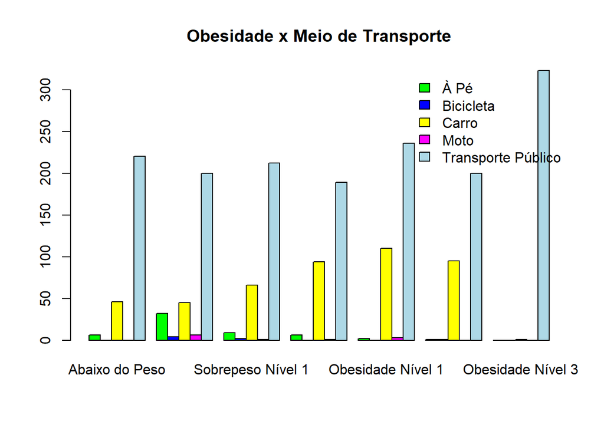

### 3.4. Interpretação dos Resultados

#### 3.4.1. Conclusão

Os resultados sugerem que o tipo de transporte utilizado está vinculado ao nível de obesidade dos indivíduos. Meios ativos de locomoção parecem associados a perfis mais saudáveis, enquanto o uso frequente de transporte público ou automóvel se relaciona com maior prevalência de sobrepeso e obesidade severa.

Esses achados levantam hipóteses importantes sobre o papel da mobilidade urbana na saúde coletiva e podem subsidiar ações voltadas à promoção do transporte ativo como estratégia preventiva contra obesidade.

## 4. Boxplot entre Variável Numérica e Categórica

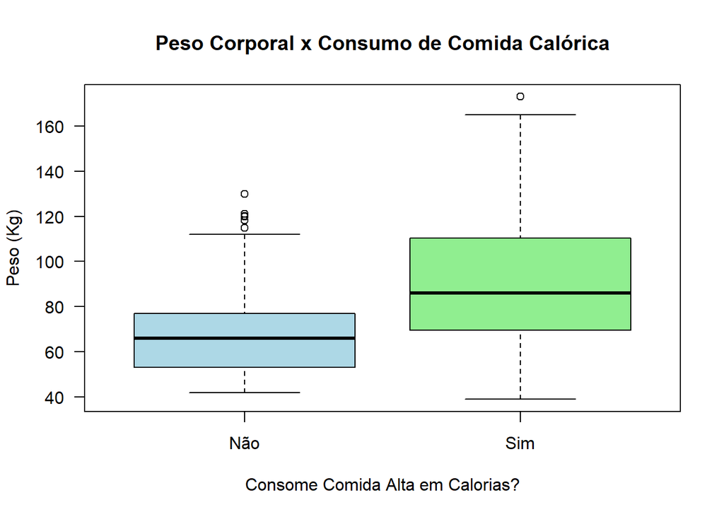

### 4.1. Interpretação dos Resultados do Boxplot

#### 4.1.1. Conclusão

Podemos perceber por meio desta análise inicial via boxplot que há indícios de uma boa relação entre a variável numérica contínua peso corporal(kg) com a variável categórica binária Consumo de comidas calóricas, indicando posssivelmente que indíviduos cujo consomem com mais frequências este tipo de alimentação tende a apresentar pesos relativaemnte maiores aqueles que não consomem, sendo um potencial fator de risco para a obesidade.

## 5. Matriz de Correlação entre Variáveis Numéricas

### 5.1. Seleção de variáveis numéricas

```r
numerica_colunas <- sapply(obesidade, is.numeric)
obesidade_numerica <- obesidade[, numerica_colunas]
```

Selecionamos apenas as colunas numéricas da base para análise de correlação entre elas.

### 5.2. Matriz de Correlação de Pearson

```
##                   Idade  Peso Altura Refeicoes_Diarias Agua_Diaria
## Idade              1.00  0.20  -0.03             -0.07       -0.05
## Peso               0.20  1.00   0.46              0.13        0.20
## Altura            -0.03  0.46   1.00              0.21        0.21
## Refeicoes_Diarias -0.07  0.13   0.21              1.00        0.07
## Agua_Diaria       -0.05  0.20   0.21              0.07        1.00
## Atividade_Fisica  -0.14 -0.05   0.30              0.11        0.17
##                   Atividade_Fisica
## Idade                        -0.14
## Peso                         -0.05
## Altura                        0.30
## Refeicoes_Diarias             0.11
## Agua_Diaria                   0.17
## Atividade_Fisica              1.00
```

Apresentamos a matriz de correlação entre todas as variáveis numéricas, arredondada para duas casas decimais. Valores positivos indicam associação direta; negativos indicam inversa.

### 5.3. Principais correlações(Maiores em Módulo)

|  | var1 | var2 | cor |
| --- | --- | --- | --- |
| 3 | Peso | Altura | 0.4622833 |
| 13 | Altura | Atividade_Fisica | 0.2953816 |
| 6 | Altura | Refeicoes_Diarias | 0.2143986 |
| 9 | Altura | Agua_Diaria | 0.2134689 |
| 1 | Idade | Peso | 0.2034432 |
| 8 | Peso | Agua_Diaria | 0.2005400 |
| 15 | Agua_Diaria | Atividade_Fisica | 0.1673441 |
| 11 | Idade | Atividade_Fisica | -0.1442263 |
| 5 | Peso | Refeicoes_Diarias | 0.1260511 |
| 14 | Refeicoes_Diarias | Atividade_Fisica | 0.1065681 |

Lista das 10 correlações mais fortes (em módulo), para destacar os pares de variáveis com maior associação linear.

### 5.4.Visualização Gráfica da Matriz

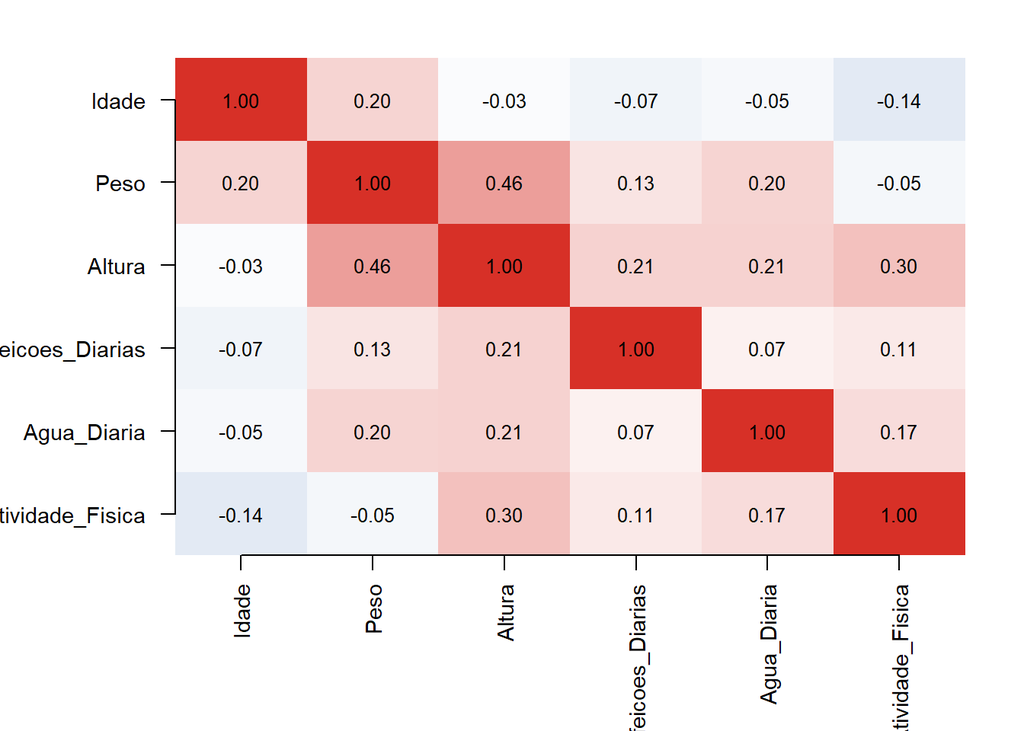

### 5.6.Interpretação dos Resultados da Matriz de Correlação numérica

- Em geral, as correlações são fracas a moderadas. Só há uma correlação moderada (Peso–Altura). Isso sugere relações lineares sutis entre as variáveis, sem indícios de multicolinearidade forte.
- Destaques:
- Peso–Altura (r≈0.46): correlação moderada positiva; pessoas mais altas tendem a pesar mais — plausível biologicamente.
- Idade–Atividade_Fisica (r≈-0.14): leve tendência de menor atividade com maior idade, mas o efeito é fraco.
- As demais correlações são fracas; úteis para sinalizar direções, mas não bastam sozinhas para conclusões fortes.

### 6. Análise Bivariada de Duas Variáveis

### 6.1. Seleção de 2 Variáveis Numéricas com Maior Correlação

```r
x <- obesidade_numerica$Altura
y <- obesidade_numerica$Peso
```

Selecionamos as variáveis Peso e Altura por terem maior correlação entre si e geralmente associadas remetem a distribuição de peso corporal por altura o que pode ser útil para avaliar a sua influência posterior no nível de obesidade.

### 6.2. Cálculo da Correlação entre Peso e Altura

```r
cor_xy <- cor(x, y, use = "complete.obs", method = "pearson")
cof_det <- cor_xy^2
cof_det
```

```
## [1] 0.2137058
```

Aqui fizemos a correlação e o teste de correlação, além do cálculo do coeficiente de determinação para construção em seguida do gráfico de dispersão com reta ajustada.

### 6.3. Cálculo do Modelo de Regressão linear entre os dois dados numéricos

```r
modelo <- lm(y ~ x)
summary(modelo)
```

```
##
## Call:
## lm(formula = y ~ x)
##
## Residuals:
##     Min      1Q  Median      3Q     Max
## -59.734 -16.376  -1.931  17.434  64.579
##
## Coefficients:
##             Estimate Std. Error t value Pr(>|t|)
## (Intercept) -134.075      9.230  -14.53   <2e-16 ***
## x            129.677      5.416   23.94   <2e-16 ***
## ---
## Signif. codes:  0 '***' 0.001 '**' 0.01 '*' 0.05 '.' 0.1 ' ' 1
##
## Residual standard error: 23.23 on 2109 degrees of freedom
## Multiple R-squared:  0.2137, Adjusted R-squared:  0.2133
## F-statistic: 573.2 on 1 and 2109 DF,  p-value: < 2.2e-16
```

### 6.4. Definição dos coeficiente da reta e do coeficiente de Determinação após regressão linear para verificar consistência com a correlação de pearson ao quadrado

```r
b0 <- coef(modelo)[1]
b1 <- coef(modelo)[2]
r2 <- summary(modelo)$r.squared
```

### 6.5. Plotagem do Gráfico de Dispersão com reta Ajustada

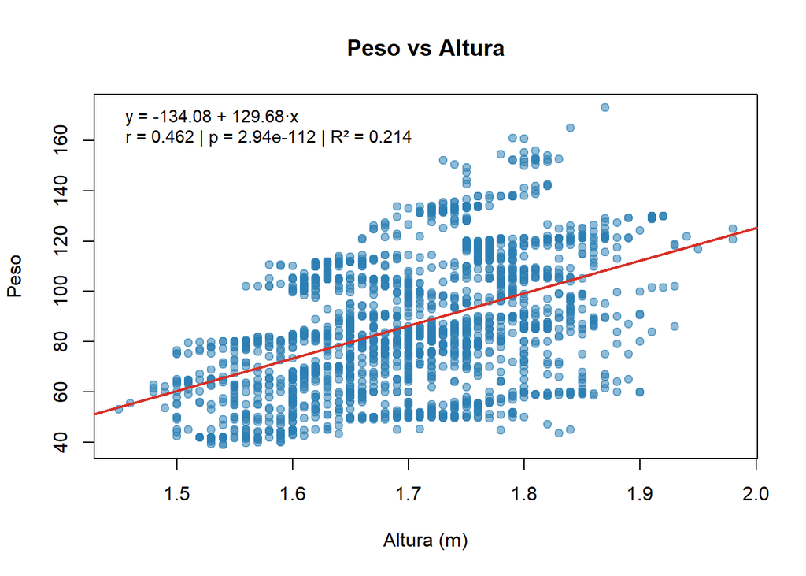

### 6.6. Interpretação do Gráfico de Dispersão de Altura vs Peso

#### 6.6.1.Interpretação dos Coeficientes

- Intercepto: -134.075 Representa o valor estimado do peso quando a altura é igual a zero. Embora esse ponto não tenha significado prático, o intercepto é necessário para definir a reta de regressão.
- Coeficiente da Altura (x): 129.677 Indica que, para cada aumento de uma unidade na altura, o peso aumenta em média 129.68 kg. Isso sugere uma relação positiva entre as variáveis.
- Ambos os coeficientes apresentam p-valores inferiores a 2e-16, demonstrando alta significância estatística. Ou seja, é extremamente improvável que essa relação tenha surgido ao acaso.

#### 6.6.2. Qualidade do Ajuste

- Coeficiente de Determinação (R²): 0.2137 Aproximadamente 21.4% da variação no peso é explicada pela altura. Esse valor revela uma associação moderada, sugerindo que outros fatores também influenciam significativamente o peso dos indivíduos.
- Erro Padrão Residual: 23.23 Representa a média da diferença entre os valores observados e os valores ajustados pela regressão. Um erro padrão mais baixo indicaria maior precisão nas estimativas.

#### 6.6.3 Conclusão desta Análise

Com base na análise estatística e no modelo ajustado, é possível concluir que existe uma relação positiva e estatisticamente significativa entre altura e peso. O coeficiente da altura demonstra que, em média, indivíduos mais altos tendem a apresentar maior peso corporal. Contudo, essa relação, embora clara, é apenas moderada: o valor de R² indica que menos de um quarto da variação no peso pode ser explicada pela altura. Isso sugere que outros fatores — como idade, sexo, composição corporal ou hábitos de vida — também desempenham papel relevante. Portanto, o modelo é útil para identificar tendências gerais, mas não é suficiente para realizar previsões precisas de peso com base apenas na altura.

## 7. Formulação e Teste de Três Perguntas

- *As perguntas a serem analisadas e respondidas com base na análise exploratória de dados serão:*

**1) Existe associação entre o tipo de transporte utilizado e o nível de obesidade?**

**2) Indivíduos que consomem comida calórica frequentemente tendem a ter maior peso corporal?**

**3)A relação entre altura e peso corporal apresenta diferenças significativas entre indivíduos com e sem histórico familiar de obesidade?**

A formulação das 3 questões propostas foram fundamentadas nas análises bivariadas executadas nos tópicos 3, 4 e 6 e robustecidas por testes estatísticos específicos para cada tipo de variável.Além disso, na pergunta 3, inicialmente é feito uma retomada da análise de peso e altura e posterior segregação dessa relação entre aqueles com e sem histórico familiar de obesidade a fim de enriquecer a análise e integrar um terceiro fator a análise bivariada para garantir uma análise mais profunda e técnica.

### 7.1. Visualização Gráfica para ajudar a responder a questão 1

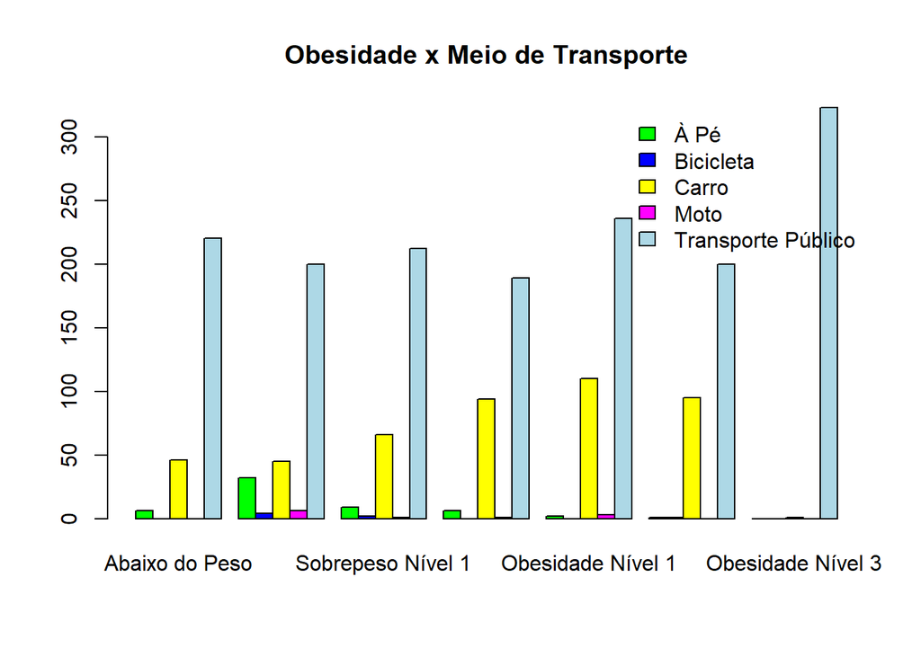

Note que o gráfico plotado aqui foi utilizado na análise entre duas variáveis categóricas aqui daremos aprofundamento da interpretação complementando com outros testes.

### 7.2. Teste do Qui-Quadrado com simulação com Monte Carlo

```r
set.seed(100)
B <- 10000
teste_chi <- chisq.test(meio_transporte_obesidade_tb, simulate.p.value = TRUE, B = B)
```

### 7.3. Resultado do Teste Qui-Quadrado

Resumo do Teste Qui-quadrado com Simulação Monte Carlo

|  | Estatistica | Graus_de_Liberdade | P_valor | Conclusao |
| --- | --- | --- | --- | --- |
| X-squared | 292.59 | NA | < 1e-04 | Associação significativa entre as variáveis |

### 7.4. Análise e Resposta a primeira Pergunta

Para responder a pergunta, avaliou-se a existência de associação entre o meio de transporte habitual e o nível de obesidade na amostra por meio do teste de independência qui-quadrado, com simulação Monte Carlo (B = 10 000). O resultado apontou estatística de X^2 = 292,59 e valor-p inferior a 0,0001. Diante desse valor-p muito menor que o nível de significância de 0,05, rejeita-se a hipótese nula de independência entre as variáveis, indicando associação estatisticamente significativa entre o tipo de transporte utilizado e o grau de obesidade dos participantes.

Portanto, esses padrões visuais corroboram o resultado do teste qui-quadrado, sugerindo que as escolhas de deslocamento estão diretamente relacionadas ao status de obesidade. Assim, conclui-se que há uma relação inversa de transportes ativos a medida que a níveis de obesidade crescem e o uso em grande parte de meios de transporte menos ativos como o transporte público, sendo portanto um fator importante para previsão da obesidade.

### 7.5. Visualização Gráfica para ajudar a responder a questão 2

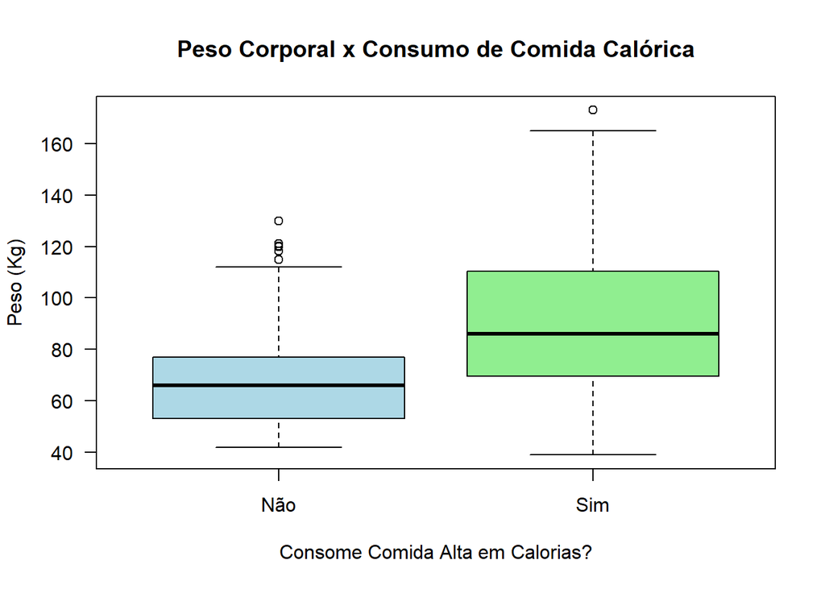

### 7.6. Análise de Distribuição de Peso Corporal por Consumo de Comida Calórica

Estatísticas de Peso por Consumo de Comida Calórica

| Comida_Alta_Caloria | Peso.n | Peso.mean | Peso.sd | Peso.se |
| --- | --- | --- | --- | --- |
| Não | 245 | 66.91 | 17.10 | 1.09 |
| Sim | 1866 | 89.17 | 26.08 | 0.60 |

### 7.7. Visualização do T test para confirmação das diferenças nas médias entre Peso Corporal e o Consumo Calórico

Resumo completo do Teste t

|  | Estatística_t | Graus_de_Liberdade | P_valor | Média_Grupo1 | Média_Grupo2 | IC_95_Lower | IC_95_Upper | Hipótese_Alternativa | Método | Conclusão |
| --- | --- | --- | --- | --- | --- | --- | --- | --- | --- | --- |
| t | -17.832 | 411 | 0 | 66.91 | 89.17 | -24.72 | -19.81 | two.sided | Welch Two Sample t-test | Diferença significativa |

### 7.8.Análise e Resposta a segunda pergunta

A análise descritiva evidenciou que indivíduos que não consomem comida alta em calorias apresentaram peso corporal médio de 66,91 kg (DP = 17,10; n = 245), enquanto aqueles que consomem apresentaram média de 89,17 kg (DP = 26,08; n = 1866). A diferença entre as médias foi de aproximadamente 22,26 kg. Para verificar a significância estatística dessa diferença, foi realizado o teste t de Welch para amostras independentes, cujo resultado indicou valor t = -17,832, com aproximadamente 411 graus de liberdade e valor-p < 0,001. O intervalo de confiança de 95% para a diferença de médias variou de -24,72 kg a -19,81 kg, não incluindo o valor nulo, o que confirma a robustez do resultado. Assim, conclui-se que indivíduos que consomem comida alta em calorias frequentemente tendem a apresentar maior peso corporal em comparação àqueles que não consomem, sendo essa diferença estatisticamente significativa. ´ Portanto, sim há uma relação muito significativo como observado pelo uso de test t pelas diferenças entre médias e desvio padrão e pelo próprio padrão observado no gráfico há uma maior peso associado a consumo de comida de alta calorias, havendo portanto uma boa relação com a obesidade em si.

### 7.9. Visualização Gráfica para ajudar a responder a questão 3

Inicialmente será plotado aqui novamente o gráfico que mostra apenas a distribuição e relação entre peso e altura a fim de fazer um comparativo entre a análise bivariada feita anteriomente com o terceiro fator de histórico de obesidade a fim de respondermosa próxima questão.

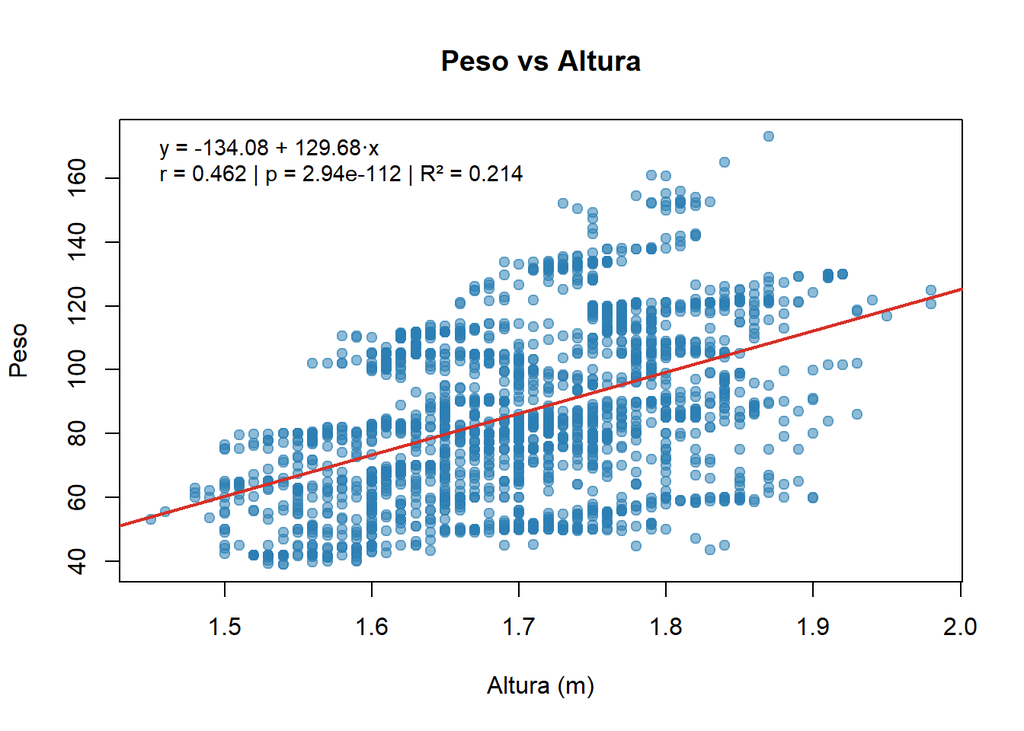

### 7.10. Separação entre grupos com histórico familiar e aqueles sem histórico de obesidade e definição do modelo de regressão linear

Coeficientes do Modelo - Grupo com Histórico Familiar ‘Sim’

| Termo | Estimativa | Erro_Padrao | t_valor | p_valor |
| --- | --- | --- | --- | --- |
| (Intercept) | -88.5938 | 10.2890 | -8.6106 | 1.61e-17 |
| Altura | 105.8813 | 5.9999 | 17.6472 | 3.35e-64 |

Resumo dos Resíduos - Grupo com Histórico Familiar ‘Sim’

| Estatistica | Valor |
| --- | --- |
| Min. | -61.2278 |
| 1º Quartil | -15.2193 |
| Mediana | 0.1219 |
| 3º Quartil | 16.5720 |
| Máx. | 63.5958 |

Métricas Gerais do Modelo - Grupo com Histórico Familiar ‘Sim’

| Estatistica | Valor |
| --- | --- |
| R-quadrado | 0.153 |
| R-quadrado Ajustado | 0.1525 |
| Erro Padrão Residual | 22.308 |
| F-Statistic | 311.4225 |
| Graus de Liberdade 1 | 1 |
| Graus de Liberdade 2 | 1724 |
| p-valor F | 3.35e-64 |

Coeficientes do Modelo - Grupo com Histórico Familiar ‘Não’

| Termo | Estimativa | Erro_Padrao | t_valor | p_valor |
| --- | --- | --- | --- | --- |
| (Intercept) | -78.9991 | 10.5101 | -7.5165 | 4.02e-13 |
| Altura | 83.5215 | 6.3487 | 13.1556 | 7.10e-33 |

Resumo dos Resíduos - Grupo com Histórico Familiar ‘Não’

| Estatistica | Valor |
| --- | --- |
| Min. | -30.3452 |
| 1º Quartil | -9.6353 |
| Mediana | -1.4987 |
| 3º Quartil | 10.1647 |
| Máx. | 39.4844 |

Métricas Gerais do Modelo - Grupo com Histórico Familiar ‘Não’

| Estatistica | Valor |
| --- | --- |
| R-quadrado | 0.3112 |
| R-quadrado Ajustado | 0.3094 |
| Erro Padrão Residual | 11.7852 |
| F-Statistic | 173.0705 |
| Graus de Liberdade 1 | 1 |
| Graus de Liberdade 2 | 383 |
| p-valor F | 7.10e-33 |

### 7.11. Plotagem de Gráfico para visualização dos dois grupos em relação ao peso e altura

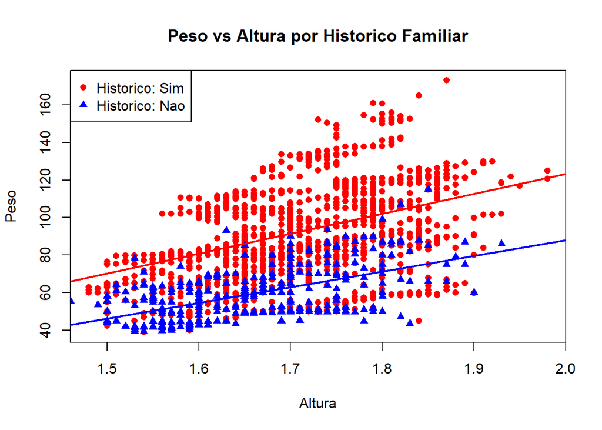

### 7.12. Utilização de Regressão linear com interação para ver se a influencia altura peso é diferente ao interagir com o histórico familiar de obesidade

Coeficientes do Modelo

| Termo | Estimativa | Erro_Padrao | t_valor | p_valor |
| --- | --- | --- | --- | --- |
| (Intercept) | -78.9991 | 18.5450 | -4.2599 | 2.14e-05 |
| Altura | 83.5215 | 11.2024 | 7.4557 | 1.30e-13 |
| Historico_Familiar_ObesidadeSim | -9.5946 | 20.8784 | -0.4595 | 0.6459 |
| Altura:Historico_Familiar_ObesidadeSim | 22.3598 | 12.5209 | 1.7858 | 0.0743 |

Resumo dos Resíduos

| Estatistica | Valor |
| --- | --- |
| Min. | -61.2278 |
| 1º Quartil | -13.4044 |
| Mediana | -0.3456 |
| 3º Quartil | 15.2839 |
| Máx. | 63.5958 |

Métricas Gerais do Modelo

| Estatistica | Valor |
| --- | --- |
| R-quadrado | 0.370506421165722 |
| R-quadrado Ajustado | 0.369610132254235 |
| Erro Padrão Residual | 20.795023792418 |
| F-Statistic | 413.3783 |
| Graus de Liberdade 1 | 3 |
| Graus de Liberdade 2 | 2107 |
| p-valor F | 3.85e-211 |

### 7.13. Uso de IMC já que peso e altura tem a maior correlação entre si utilizando IMC que relaciona as duas conseguimos ao mesmo tempo relacionar com o historico familiar obesidade além de uso de t test para validar a possível hipótese

Resultados do Teste t para IMC

[output not shown]

Coeficientes do Modelo Linear para IMC

| Termo | Estimativa | Erro_Padrao | t_valor | p_valor |
| --- | --- | --- | --- | --- |
| (Intercept) | 21.4997 | 0.3577 | 60.1060 | 0.00e+00 |
| Historico_Familiar_ObesidadeSim | 10.0333 | 0.3956 | 25.3633 | 4.31e-124 |

Resumo dos Resíduos do Modelo IMC

| Estatistica | Valor |
| --- | --- |
| Min. | -18.2415 |
| 1º Quartil | -4.6408 |
| Mediana | -0.0315 |
| 3º Quartil | 4.9265 |
| Máx. | 19.2872 |

Métricas Gerais do Modelo Linear para IMC

| Estatistica | Valor |
| --- | --- |
| R-quadrado | 0.2337 |
| R-quadrado Ajustado | 0.2334 |
| Erro Padrão Residual | 7.0185 |
| F-Statistic | 643.2993 |
| Graus de Liberdade 1 | 1 |
| Graus de Liberdade 2 | 2109 |
| p-valor F | 4.31e-124 |

### 7.14. Análise e Resposta a terceira pergunta

Para investigar se a relação entre altura e peso corporal apresenta diferenças significativas entre indivíduos com e sem histórico familiar de obesidade, realizamos uma análise de regressão linear separada para cada grupo, bem como uma análise de regressão com termo de interação.

Modelos de regressão separados:

Para o grupo com histórico familiar de obesidade, o modelo de regressão linear mostrou que a altura é um preditor significativo do peso corporal (p < 0.001), com coeficiente estimado de 105.88 (Erro padrão = 6.00). O modelo apresentou um R² de 0.153, indicando que aproximadamente 15,3% da variação do peso é explicada pela altura neste grupo.

Para o grupo sem histórico familiar, a altura também foi um preditor significativo do peso (p < 0.001), com coeficiente estimado de 83.52 (Erro padrão = 6.35). Neste caso, o R² foi de 0.311, indicando maior explicação da variação do peso pela altura nesse grupo (31,1%).

Modelo de regressão com interação:

Ao incluir o termo de interação entre altura e histórico familiar de obesidade no modelo, verificamos que o coeficiente da interação (Altura:Histórico_Familiar_ObesidadeSim) foi positivo (22.36) e próximo do limiar de significância estatística (p = 0.0743), sugerindo uma tendência para que a relação entre altura e peso seja mais acentuada para indivíduos com histórico familiar de obesidade, embora não tenha atingido significância estatística ao nível de 5%.

Visualização gráfica:

Os gráficos de dispersão e as linhas de regressão ajustadas para cada grupo corroboram os resultados, mostrando inclinações maiores para o grupo com histórico familiar, evidenciando uma relação mais forte entre altura e peso nesse grupo.

Conclusão:

Os dados indicam que existe uma diferença na relação entre altura e peso corporal entre indivíduos com e sem histórico familiar de obesidade, sendo a relação mais forte (maior coeficiente) para aqueles com histórico familiar. Contudo, essa diferença não atingiu significância estatística convencional no modelo de interação (p > 0.05), sugerindo que, embora haja uma tendência, não podemos afirmar com plena confiança estatística que a influência da altura no peso difere de forma significativa entre os grupos.